# Encyclopédie des JO (1992-2024)

Racine Eva

2024-10-04

# LE SAUT EN LONGUEUR

[figure not shown]

*Miltiadis Tentoglou, médaillé d’Or aux JO 2024 - Crédits L’Équipe*

## Introduction

Le saut en longueur fait partie intégrante des Jeux Olympiques modernes depuis leur première édition en 1896 et constitue une épreuve majeure de l’athlétisme, discipline la plus suivie des JO. Le saut en longueur trouve son origine dans la Grèce Antique et était pratiqué à cette époque durant le pentathlon, une discipline qui regroupait 5 épreuves : le lancer du disque et du javelot, le saut en longueur, la lutte et la course.

L’américain Bob Beamon détient le record olympique masculin de saut en longueur avec 8,90 m (JO 1968, Mexico) et l’américaine Jackie Joyner-Kersee détient le record féminin avec 7,40 m (JO 1988, Séoul).

L’objectif de cette note est d’analyser les résultats dans cette discipline olympique de 1992 à 2024 en étudiant les caractéristiques des sportifs ayant obtenu une médaille (Or, Argent, Bronze). Nous allons plus précisément essayer de répondre aux questions suivantes :

- **Quelles sont les caractéristiques physiques des médaillés ?**
- **Quelles sont les nationalités des médaillés ?**

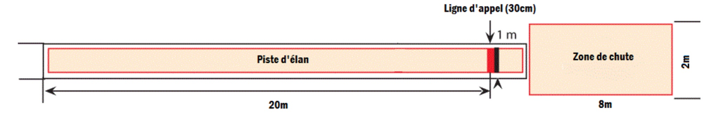

*Schéma d’une piste de saut en longueur - Crédits OlympiadesJacquesRousseau*

## Données

Le jeu de données qui nous a été fourni comme point de départ est issu d’une base de donnée accessible sur Kaggle et intitulée [120 years of olympic results : athlets and results](https://www.kaggle.com/datasets/heesoo37/120-years-of-olympic-history-athletes-and-results). Comme cette base de donnée s’arrête en 2016, nous avons essayé de compléter les données pour les JO de 2020 (Tokyo) et 2024 (Paris). Nous avons utilisé les données de [Wikipedia](https://fr.wikipedia.org/wiki/Saut_en_longueur_aux_Jeux_olympiques#Palmarès) pour les ajouter manuellement au document CSV.

Voici un extrait du jeu de données (le tableau complet est en annexe)

```
##                                             nom   sex age poids taille pays
## 1             Heike Gabriela Drechsler (Daute-) Femme  27    68    181  GER
## 2 Inesa Mykolavna Kravets (Shuliak-, -Izvachuk) Femme  25    60    178  EUN
## 3         Jacqueline \\Jackie\\" Joyner-Kersee" Femme  30    70    178  USA
##    ann    titre
## 1 1992     1.Or
## 2 1992 2.Argent
## 3 1992 3.Bronze
```

On peut vérifier s’il manque des données pour certains athlètes :

```
##              nom   sex age poids taille pays  ann    titre
## 41 Luvo Manyonga Homme  25    NA     NA  RSA 2016 2.Argent
```

On remarque qu’il manque le poids et la taille d’un athlète, Luvo Manyonga, qui a gagné la médaille d’Argent aux JO de 2016.

## Caractéristique physiques des vainqueurs

Les caractéristiques physiques telles que le poids, la taille ou l’âge sont des éléments clés dans la performance des athlètes, notamment dans le saut en longueur. Pour analyser les vainqueurs des médailles olympiques en saut en longueur 1992 à 2024, nous nous concentrerons sur les différences entre hommes et femmes dans ces trois variables. Cette analyse nous permettra de comprendre les profils physiques typiques des champions et d’identifier d’éventuelles différences entre les sexes.

#### L’âge des athlètes

On remarque que les championnes olympiques ont un âge moyen de **27.3 ans** tandis que les hommes on un âge moyen de **25.2 ans**. En moyenne, les médaillées féminines sont plus agées lors de l’obtention de leur médailles que leurs homologues masculins. Pour les deux sexes, l’âge minimum observé est de 19 ans et l’âge maximum est de 35 ans. **L’écart-type** de **3.95** pour les femmes et **3.49** pour les hommes montre que les âges des médaillés féminins sont légèrement plus dispersés autour de la moyenne que ceux des hommes. Un écart type plus élevé pour les femmes peut indiquer une plus grande variabilité dans l’âge des athlètes féminines qui ont réussi à obtenir une médaille.

On peut observer cela avec un graphique sur la répartition des âges des athlètes par sexe:

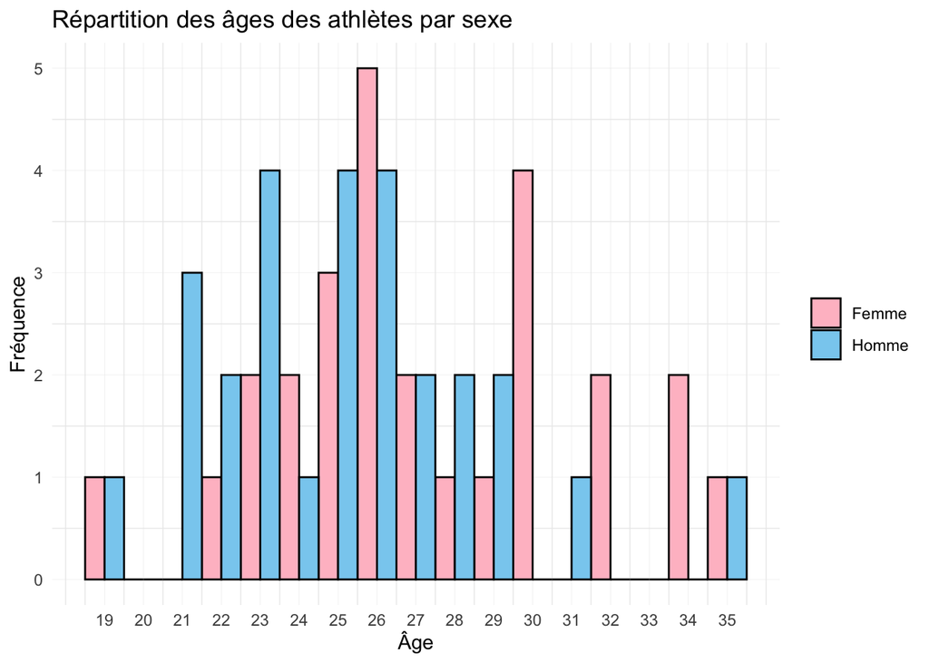

#### La taille des athlètes

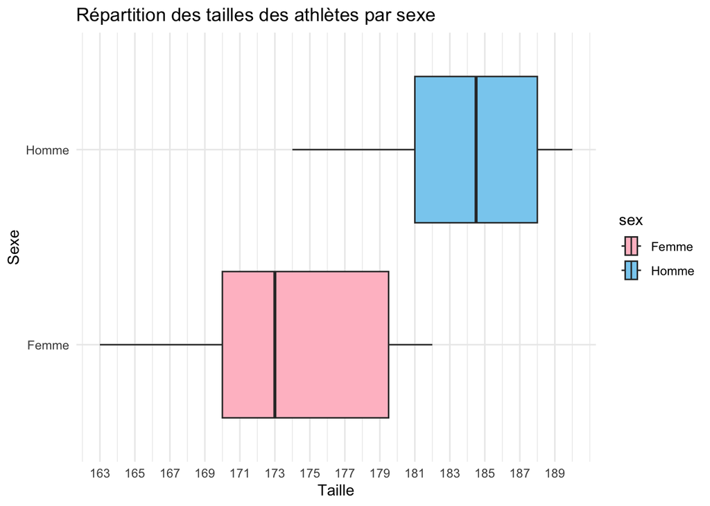

On observe que la taille moyenne des athlètes féminines médaillées est de **173,9cm**, avec une variation entre **163cm** pour la plus petite et **182cm** pour la plus grande. L’écart type de **5,8cm** indique une certaine variabilité des tailles chez les femmes. Chez les hommes, la taille moyenne est plus élevée, à **183,5cm**, avec un minimum de **174cm** et un maximum de **190cm**. L’écart type de **4,42cm** suggère une variabilité légèrement plus faible par rapport aux femmes, indiquant que la taille des athlètes masculins médaillés est plus homogène.

#### Le poids des athlètes

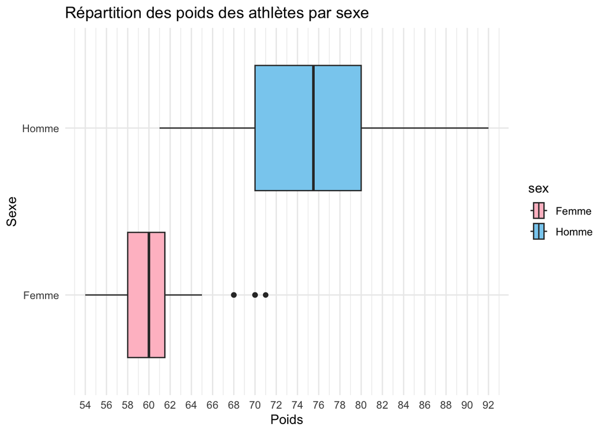

**Chez les femmes**, le poids moyen est de **61,15kg**, avec des variations allant de **54kg** à **71kg**. La médiane se situe à **60kg**, ce qui montre que la majorité des athlètes féminines se situent légèrement en dessous de la moyenne. L’écart-type, qui est de **4,59kg**, montre une faible dispersion autour de la moyenne, ce qui suggère que la plupart des athlètes féminines ont un poids relativement proche les unes des autres.

**Chez les hommes**, le poids moyen est plus élevé, atteignant **75,62kg**. Le poids des athlètes masculins varie entre **61kg** et **92kg**, avec une médiane de **75,5kg**. Ici, l’écart-type est de **7,68kg**, ce qui montre une plus grande dispersion des poids chez les hommes par rapport aux femmes. Cela signifie que le poids des athlètes masculins varie davantage.

#### IMC des athlètes

```
## $Femme
##    Min. 1st Qu.  Median    Mean 3rd Qu.    Max.
##   17.81   19.61   20.38   20.23   21.08   22.09
##
## $Homme
##    Min. 1st Qu.  Median    Mean 3rd Qu.    Max.    NA's
##   19.84   20.90   22.13   22.42   23.55   26.03       1
```

Les athlètes féminines présentent un IMC moyen de **20,23**, avec des valeurs allant de **17,81** à **22,09**, ce qui reflète une répartition assez équilibrée autour de la moyenne. Chez les hommes, l’IMC moyen est plus élevé, à **22,42**, avec une variation de **19,84** à **26,03**, indiquant une plus grande dispersion des indices et des corpulences plus variées.

## Nationalité des vainqueurs

Nous allons maintenant étudier la nationalité des médaillés de saut en longueur olympique, en mettant en lumière les pays qui se distinguent par leur succès dans cette discipline.

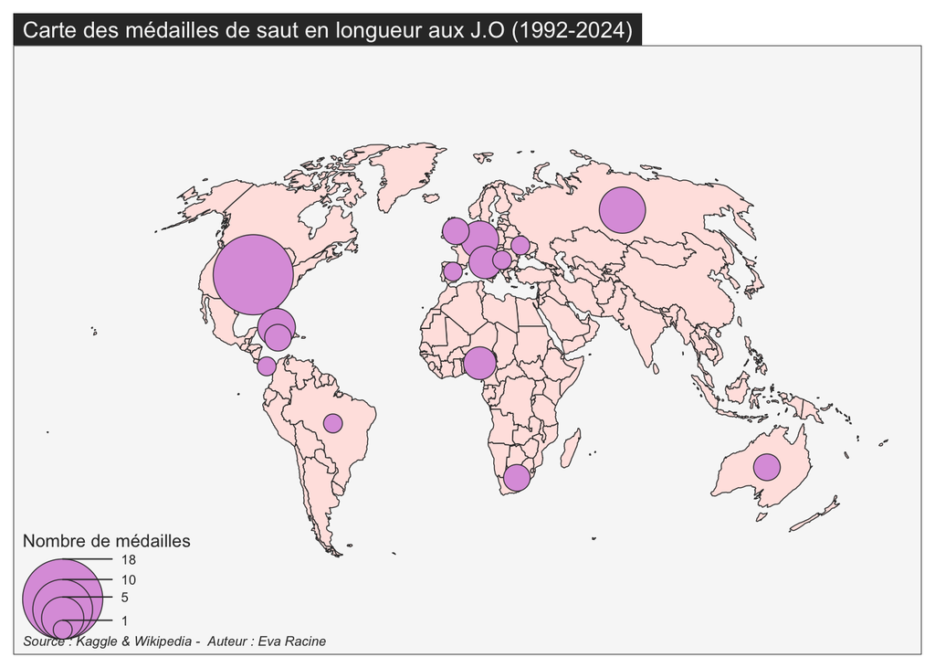

On remarque que les **États-Unis** dominent largement le classement de saut en longueur avec **18** médailles, soit le triple de la Russie qui arrive en deuxième position avec **6** médailles entre 1992 et 2024. Cette domination américaine peut s’expliquer par la forte culture du développement sportif dans le pays. Aux États-Unis, l’athlétisme est un sport important, avec un système éducatif qui encourage la pratique intensive à travers les compétitions scolaires et universitaires. Les infrastructures de haut niveau, les programmes de soutien aux athlètes, ainsi que la présence d’entraîneurs qualifiés favorisent l’émergence de talents dans des disciplines comme le saut en longueur.

Sur la carte, on observe que les médailles se concentrent majoritairement en **Europe** et en **Amérique du Nord**. Les pays comme l’Allemagne ou la Russie ont également une longue tradition en athlétisme, ce qui explique leur récurrence parmi les vainqueurs.

Regardons maintenant en différenciant les hommes des femmes :

```
## # A tibble: 2 × 18
##   sex     AUS   BRA   CUB   ESP   EUN   GBR   GER   GRE   ITA   JAM   NGR   PAN
##   <fct> <int> <int> <int> <int> <int> <int> <int> <int> <int> <int> <int> <int>
## 1 Homme     2    NA     4     1    NA     2    NA     2     1     2    NA     1
## 2 Femme    NA     1    NA    NA     1    NA     4    NA     2    NA     3    NA
## # ℹ 5 more variables: RSA <int>, RUS <int>, SRB <int>, UKR <int>, USA <int>
```

L’analyse révèle que la Russie, deuxième du classement, a remporté 6 médailles exclusivement grâce aux femmes. Les États-Unis se distinguent avec un total 9 médailles pour les hommes et 9 pour les femmes, montrant une forte performance des deux sexes. Ces résultats soulignent des disparités significatives entre les performances masculines et féminines dans certains pays.

## Annexe

### Données sur les hommes

Annexe 1 : Champions olympiques de saut en longueur 1992-2024

|  | nom | sex | age | poids | taille | pays | ann | titre | IMC |
| --- | --- | --- | --- | --- | --- | --- | --- | --- | --- |
| 22 | Frederick Carlton " Lewis” | Homme | 31 | 80 | 188 | USA | 1992 | 1.Or | 22.63468 |
| 23 | Michael Anthony " Powell” | Homme | 28 | 77 | 188 | USA | 1992 | 2.Argent | 21.78588 |
| 24 | Joseph Tilford Lee " Greene” | Homme | 25 | 70 | 183 | USA | 1992 | 3.Bronze | 20.90239 |
| 25 | Frederick Carlton " Lewis” | Homme | 35 | 80 | 188 | USA | 1996 | 1.Or | 22.63468 |
| 26 | James Charles Beckford | Homme | 21 | 78 | 178 | JAM | 1996 | 2.Argent | 24.61810 |
| 27 | Joseph Tilford Lee " Greene” | Homme | 29 | 70 | 183 | USA | 1996 | 3.Bronze | 20.90239 |
| 28 | Ivn Lzaro Pedroso Soler | Homme | 27 | 66 | 176 | CUB | 2000 | 1.Or | 21.30682 |
| 29 | Jai Desmond Taurima | Homme | 28 | 80 | 188 | AUS | 2000 | 2.Argent | 22.63468 |
| 30 | Roman Anatoliyovych Shchurenko | Homme | 23 | 82 | 188 | UKR | 2000 | 3.Bronze | 23.20054 |
| 31 | Dwight D. Phillips | Homme | 26 | 73 | 185 | USA | 2004 | 1.Or | 21.32944 |
| 32 | John Moffitt | Homme | 23 | 78 | 185 | USA | 2004 | 2.Argent | 22.79036 |
| 33 | Joan Lino Martnez Armenteros | Homme | 26 | 69 | 176 | ESP | 2004 | 3.Bronze | 22.27531 |
| 34 | Irving Jahir Saladino Arana | Homme | 25 | 70 | 183 | PAN | 2008 | 1.Or | 20.90239 |
| 35 | Godfrey Khotso Mokoena | Homme | 23 | 76 | 190 | RSA | 2008 | 2.Argent | 21.05263 |
| 36 | Ibrahim Camejo Savas | Homme | 26 | 79 | 180 | CUB | 2008 | 3.Bronze | 24.38272 |
| 37 | Gregory James " Rutherford” | Homme | 25 | 92 | 188 | GBR | 2012 | 1.Or | 26.02988 |
| 38 | Mitchell " Watt” | Homme | 24 | 83 | 184 | AUS | 2012 | 2.Argent | 24.51560 |
| 39 | William Bundu " Claye” | Homme | 21 | 72 | 181 | USA | 2012 | 3.Bronze | 21.97735 |
| 40 | Jeffrey " Henderson” | Homme | 27 | 86 | 183 | USA | 2016 | 1.Or | 25.68007 |
| 41 | Luvo Manyonga | Homme | 25 | NA | NA | RSA | 2016 | 2.Argent | NA |
| 42 | Gregory James " Rutherford” | Homme | 29 | 92 | 188 | GBR | 2016 | 3.Bronze | 26.02988 |
| 43 | Miltiadis Tentoglou | Homme | 22 | 70 | 185 | GRE | 2020 | 1.Or | 20.45289 |
| 44 | Juan Miguel Echevarria | Homme | 22 | 72 | 186 | CUB | 2020 | 2.Argent | 20.81165 |
| 45 | Maykel Masso | Homme | 21 | 61 | 174 | CUB | 2020 | 3.Bronze | 20.14797 |
| 49 | Miltiadis Tentoglou | Homme | 26 | 70 | 185 | GRE | 2024 | 1.Or | 20.45289 |
| 50 | Wayne Pinnock | Homme | 23 | 75 | 178 | JAM | 2024 | 2.Argent | 23.67125 |
| 51 | Mattia Furlani | Homme | 19 | 65 | 181 | ITA | 2024 | 3.Bronze | 19.84066 |

### Données sur les femmes

Annexe 2 : Championnes olympiques de saut en longueur 1992-2024

|  | nom | sex | age | poids | taille | pays | ann | titre | IMC |
| --- | --- | --- | --- | --- | --- | --- | --- | --- | --- |
| 1 | Heike Gabriela Drechsler (Daute-) | Femme | 27 | 68 | 181 | GER | 1992 | 1.Or | 20.75639 |
| 2 | Inesa Mykolavna Kravets (Shuliak-, -Izvachuk) | Femme | 25 | 60 | 178 | EUN | 1992 | 2.Argent | 18.93700 |
| 3 | Jacqueline " Joyner-Kersee” | Femme | 30 | 70 | 178 | USA | 1992 | 3.Bronze | 22.09317 |
| 4 | Chioma Ajunwa (-Opara) | Femme | 24 | 57 | 164 | NGR | 1996 | 1.Or | 21.19274 |
| 5 | Fiona Winsome Marcia May (-Iapichino) | Femme | 26 | 60 | 181 | ITA | 1996 | 2.Argent | 18.31446 |
| 6 | Jacqueline " Joyner-Kersee” | Femme | 34 | 70 | 178 | USA | 1996 | 3.Bronze | 22.09317 |
| 7 | Heike Gabriela Drechsler (Daute-) | Femme | 35 | 68 | 181 | GER | 2000 | 1.Or | 20.75639 |
| 8 | Fiona Winsome Marcia May (-Iapichino) | Femme | 30 | 60 | 181 | ITA | 2000 | 2.Argent | 18.31446 |
| 9 | Tatyana Vladimirovna Kotova | Femme | 23 | 59 | 182 | RUS | 2000 | 3.Bronze | 17.81186 |
| 10 | Tatyana Romanovna Lebedeva | Femme | 28 | 61 | 170 | RUS | 2004 | 1.Or | 21.10727 |
| 11 | Irina Alekseyevna Simagina (-Meleshina) | Femme | 22 | 56 | 171 | RUS | 2004 | 2.Argent | 19.15119 |
| 12 | Tatyana Vladimirovna Kotova | Femme | 27 | 59 | 182 | RUS | 2004 | 3.Bronze | 17.81186 |
| 13 | Maurren Higa Maggi | Femme | 32 | 61 | 173 | BRA | 2008 | 1.Or | 20.38157 |
| 14 | Tatyana Romanovna Lebedeva | Femme | 32 | 61 | 170 | RUS | 2008 | 2.Argent | 21.10727 |
| 15 | Blessing Okagbare (-Ighoteguonor) | Femme | 19 | 71 | 181 | NGR | 2008 | 3.Bronze | 21.67211 |
| 16 | Brittney Davon Reese | Femme | 25 | 61 | 173 | USA | 2012 | 1.Or | 20.38157 |
| 17 | Yelena Aleksandrovna Sokolova (Kremnyova-) | Femme | 26 | 61 | 170 | RUS | 2012 | 2.Argent | 21.10727 |
| 18 | Cynthia " DeLoach (-Soukup)” | Femme | 26 | 58 | 166 | USA | 2012 | 3.Bronze | 21.04805 |
| 19 | Tianna Madison-Bartoletta | Femme | 30 | 58 | 168 | USA | 2016 | 1.Or | 20.54989 |
| 20 | Brittney Davon Reese | Femme | 29 | 61 | 173 | USA | 2016 | 2.Argent | 20.38157 |
| 21 | Ivana panovi | Femme | 26 | 65 | 176 | SRB | 2016 | 3.Bronze | 20.98399 |
| 46 | Malaika Mihambo | Femme | 26 | 58 | 171 | GER | 2020 | 1.Or | 19.83516 |
| 47 | Brittney Davon Reese | Femme | 34 | 62 | 173 | USA | 2020 | 2.Argent | 20.71569 |
| 48 | Ese Brume | Femme | 24 | 56 | 167 | NGR | 2020 | 3.Bronze | 20.07960 |
| 52 | Tara Davis | Femme | 25 | 54 | 163 | USA | 2024 | 1.Or | 20.32444 |
| 53 | Malaika Mihambo | Femme | 30 | 58 | 171 | GER | 2024 | 2.Argent | 19.83516 |
| 54 | Jasmine Moore | Femme | 23 | 58 | 173 | USA | 2024 | 3.Bronze | 19.37920 |